# Prosper Loan Data Exploration

## by Kudakwashe Verah

## Investigation Overview

In this presentation, I focused on the relationship between the variables that would have the largest impact on the outcome of a loan. I begin by introducing the features one by one then proceed to how they relate with each other and then eventually how they relate to the monthly repayments and the original loan amount.

## Dataset Overview

The data consists of information regarding 113,937 loans with 81 variables on each loan, including loan amount, borrower rate (or interest rate), current loan status, borrower income, and many others.

## Distribution of Loan Status

There are 12 different loan statuses with counts ranging from less than 50 to over 50,000. To best observe the distribution of the loans by their status, we plotted a horizontal bar graph with each status's proportion shown.

The 'Current' loan type makes up 49.7% of the total loans in the dataset. When we combine it with the 'Completed, 'Chardgedoff', and 'Default' loan types, they make up approximately 98% of all the loans in the dataset.

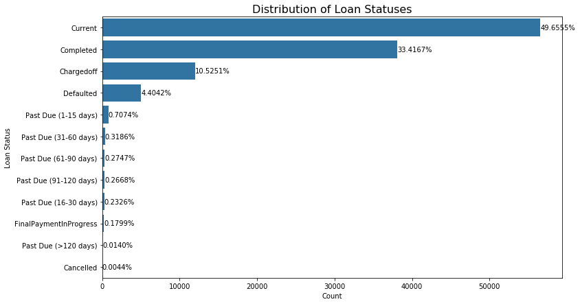

## Distribution of Interest Rate

Most of the loans have an interest rate between 5% and 35% and the highest peaks were around 14%, 19%, 25%, 32% and 35% - with the maximum peak being the one at 32%.

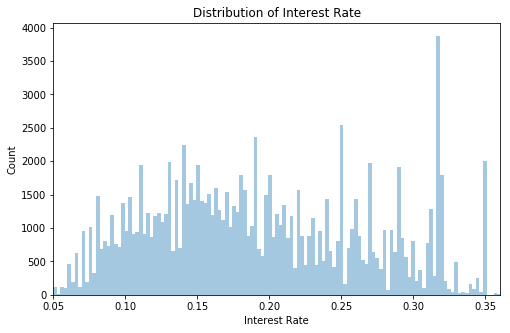

## Distribution of Original Loan Amounts and Monthly Repayments

For the Original loan amounts, we have peaks at the standard loan amounts you'd expect, these are, \$5,000, \$10,000, \$15,000, \$20,000 and \$25,000. The most common original loan amount is \$4,000.

The most common monthly repayment is \$150.

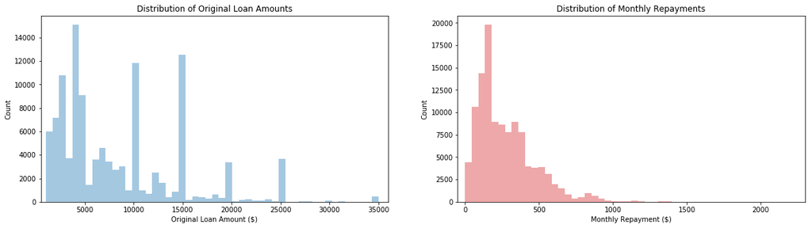

## Monthly Repayments vs Original Loan Amounts

There is no evidence of a relationship between any of the numeric variables except for the original loan amount and the monthly loan repayments. This plot shows 4 lines of positive correlation, which is interesting. I investigated this relationship in a visualisation to come.

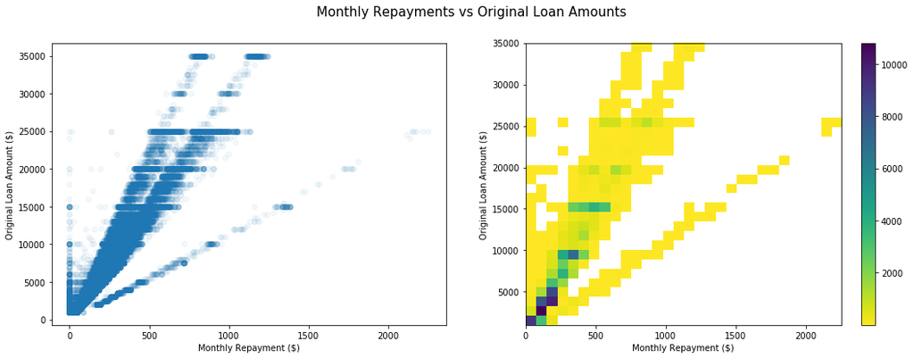

## Original Loan Amounts by Income Range and Credit Ratings

From these plots, it was evident that as the borrower's income increased, their median original loan amounts also increased.

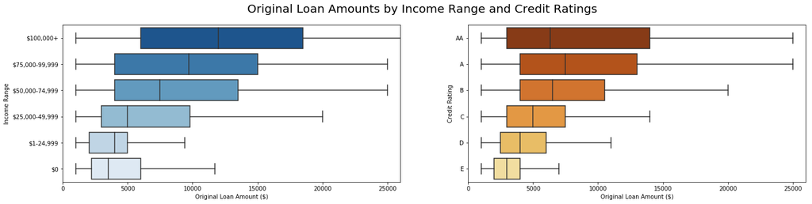

## Monthly Repayments by Income Range and Credit Ratings

There was a similar relationship in these plots with the monthly repayments as I had observed in the original loan amounts plots. This was more evidence indicating that there is a positive correlation between the variables as we had previously seen.

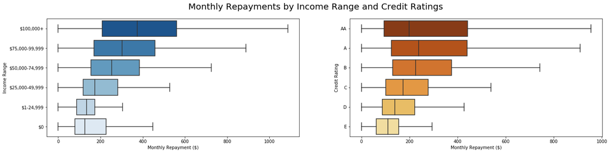

## Correlation of Monthly Repayments and Original Loan Amounts by Loan Status and Loan Term

From the previous visualisation, I knew that there was a positive correlation between the monthly repayments and original loan amounts, but I felt that this relationship wasn't fully visible. As such, I decided to split the data into 4 labour statuses: Completed, Current, Chargedoff and Defaulted and put them in columns based on the loan terms: 12, 36 or 60 months.

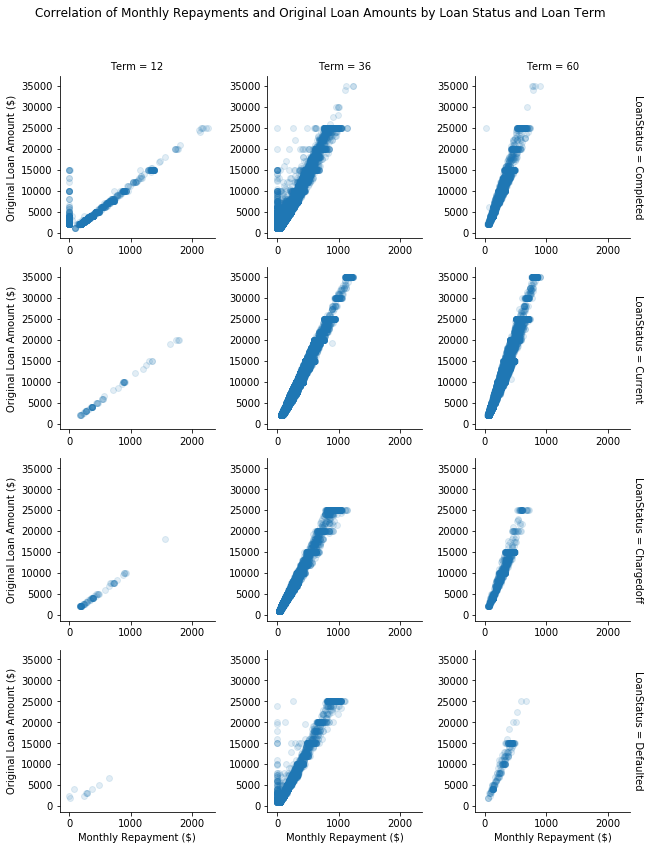

## Median Original Loan Amount, Monthly Repayment and Interest Rate by Income Ranges and Credit Ratings

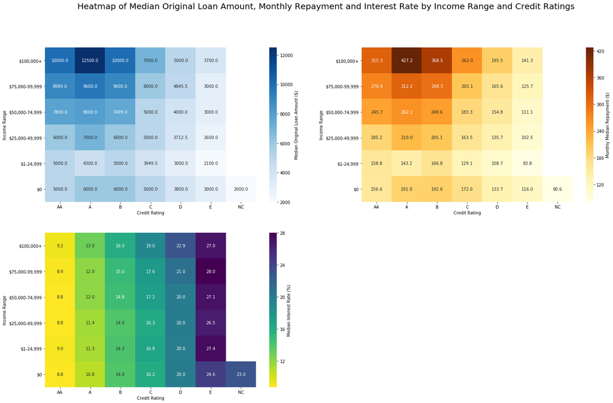